# Latihan Pertemuan 7 : Diagnostik Model & Peramalan - Adinda Shabrina Putri Salsabila

# Packages

```r
library(ggplot2)
library(tsibble)
library(tseries)
library(MASS)
library(forecast)
library(TSA)
library(TTR)
library(aTSA)
library(graphics)
```

# Data

Digunakan data harga cabai rawit di wilayah Jakarta yang dalam hal ini hanya digunakan data 140 periode akhir

```r
data <- read.csv("C:/Users/hp/Documents/datampdw6.csv")
datacabai.ts <- ts(data)
head(datacabai.ts)
```

```
## Time Series:
## Start = 1
## End = 6
## Frequency = 1
##      harga
## [1,] 81090
## [2,] 80000
## [3,] 90670
## [4,] 85730
## [5,] 84340
## [6,] 75040
```

# Eksplorasi Data

## Plot Data Penuh

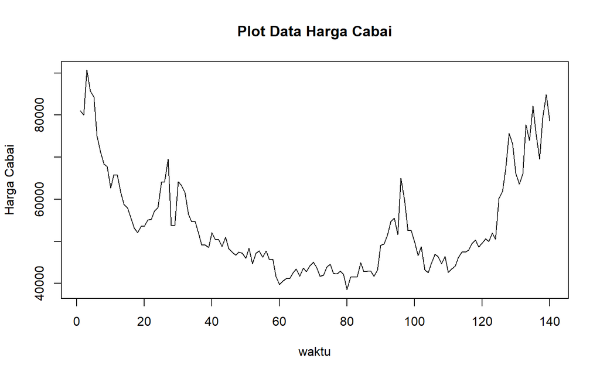

```r
plot.ts(datacabai.ts, lty=1, xlab="waktu", ylab="Harga Cabai", main="Plot Data Harga Cabai")
```

Berdasarkan plot data deret waktu, terlihat adanya tren jangka panjang yang fluktuatif. Data dimulai dengan harga tinggi, kemudian menurun secara umum hingga sekitar titik data ke-80, lalu mulai menunjukkan tren kenaikan kembali hingga akhir periode.Juga adanya indikasi pola siklis, ditunjukkan oleh fluktuasi yang berulang dalam jangka waktu yang lebih panjang. Terlihat beberapa siklus naik-turun sepanjang periode waktu yang ditampilkan. Berdasarkan pola data, pembagian data latih dan data uji ditetapkan dengan proporsi 71%:29%.

## Plot Data Latih

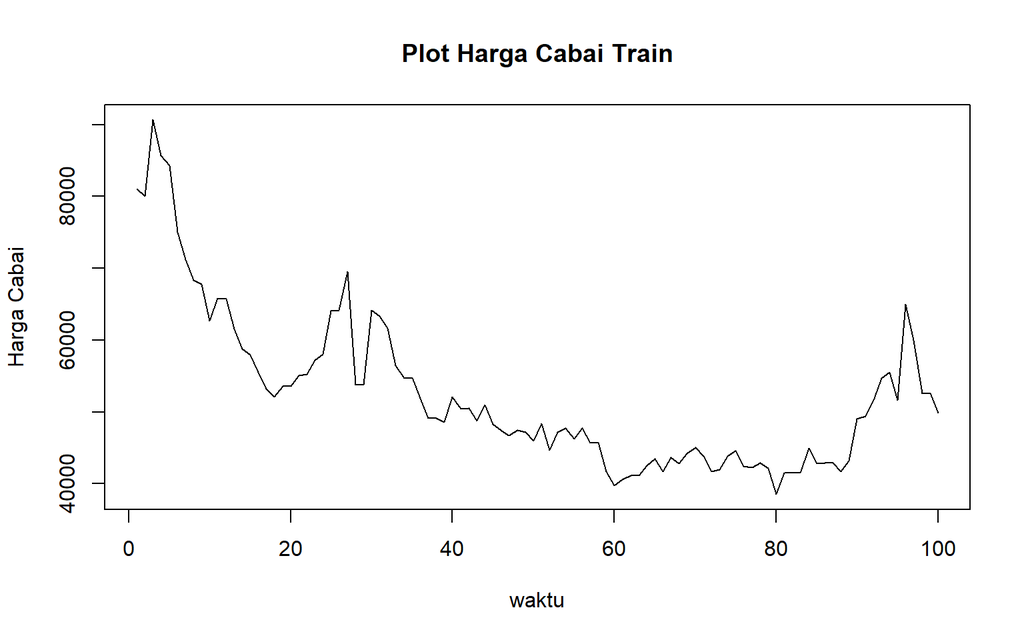

```r
cabaitrain<-datacabai.ts[1:100]
train.ts<-ts(cabaitrain)
plot.ts(train.ts, lty=1, xlab="waktu", ylab="Harga Cabai", main="Plot Harga Cabai Train")
```

Berdasarkan plot data deret waktu pada data latih, terlihat bahwa data cenderung memiliki trend yang naik-turun dan cenderung tidak bergerak pada nilai tengah tertentu. Hal ini mengindikasikan bahwa data tidak stasioner dalam rataan.

## Plot Data Uji

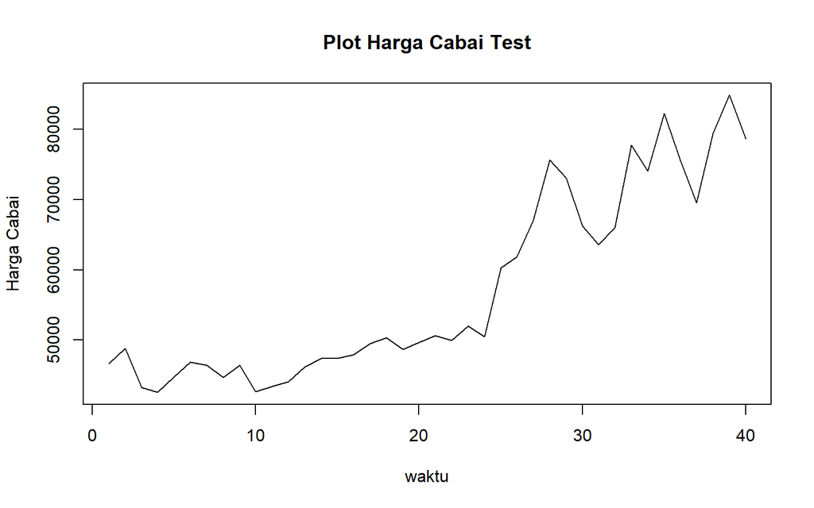

```r
cabaitest<-datacabai.ts[101:140]
test.ts<-ts(cabaitest)
plot.ts(test.ts, lty=1, xlab="waktu", ylab="Harga Cabai", main="Plot Harga Cabai Test")
```

# Uji Stasioneritas Data

## Plot ACF

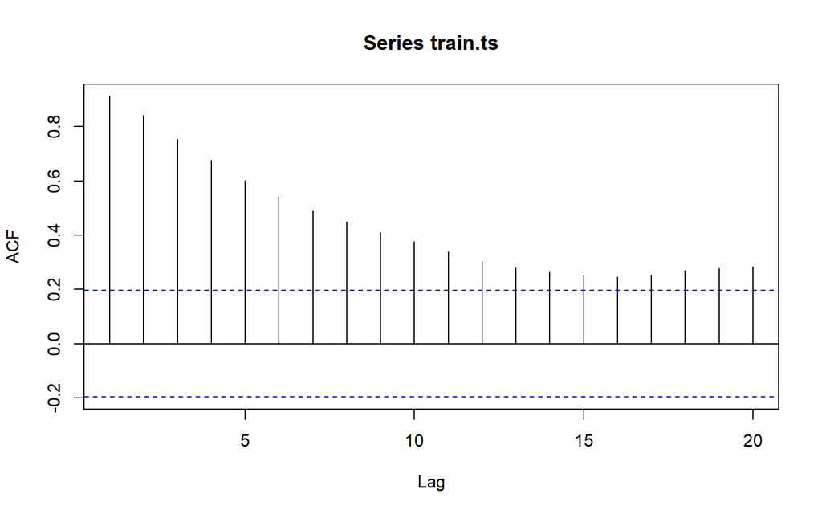

```r
acf(train.ts)
```

Berdasarkan plot ACF, terlihat bahwa plot ACF data menurun secara perlahan (*tails of slowly*). Hal ini juga menjadi indikasi bahwa data tidak stasioner dalam rataan

## Uji ADF

```r
tseries::adf.test(train.ts)
```

```
##
##  Augmented Dickey-Fuller Test
##
## data:  train.ts
## Dickey-Fuller = -3.1755, Lag order = 4, p-value = 0.09586
## alternative hypothesis: stationary
```

$H_0$ : Data tidak stasioner dalam rataan

$H_1$ : Data stasioner dalam rataan

Berdasarkan uji ADF tersebut, didapat *p-value* sebesar 0.09586 yang lebih besar dari taraf nyata 5% sehingga tak tolak $H_0$ dan menandakan bahwa data tidak stasioner dalam rataan. Hal ini sesuai dengan hasil eksplorasi menggunakan plot time series dan plot ACF, sehingga ketidakstasioneran model kedepannya harus ditangani

## Plot Box-Cox

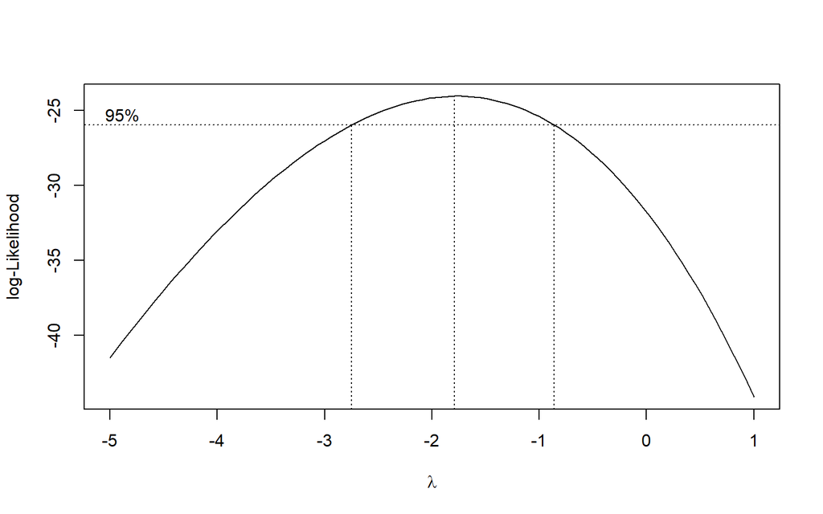

```r
index <- seq(1:100)
bc = boxcox(train.ts~index, lambda = seq(-5,by=1))
```

```r
#Nilai Rounded Lambda
lambda <- bc$x[which.max(bc$y)]
lambda
```

```
## [1] -1.787879
```

```r
#SK
bc$x[bc$y > max(bc$y) - 1/2 * qchisq(.95,1)]
```

```
##  [1] -2.6969697 -2.6363636 -2.5757576 -2.5151515 -2.4545455 -2.3939394
##  [7] -2.3333333 -2.2727273 -2.2121212 -2.1515152 -2.0909091 -2.0303030
## [13] -1.9696970 -1.9090909 -1.8484848 -1.7878788 -1.7272727 -1.6666667
## [19] -1.6060606 -1.5454545 -1.4848485 -1.4242424 -1.3636364 -1.3030303
## [25] -1.2424242 -1.1818182 -1.1212121 -1.0606061 -1.0000000 -0.9393939
## [31] -0.8787879
```

Plot Boxcox menunjukkan nilai *rounded value* ($\lambda$) optimum sebesar **-1.787879** dan pada selang kepercayaan 95% nilai memiliki batas bawah **-2.6969697** dan batas atas **-0.8787879**. Selang tersebut tidak memuat nilai satu sehingga dapat dikatakan bahwa data tidak stasioner dalam ragam.

# Penanganan Ketidakstasioneran Data

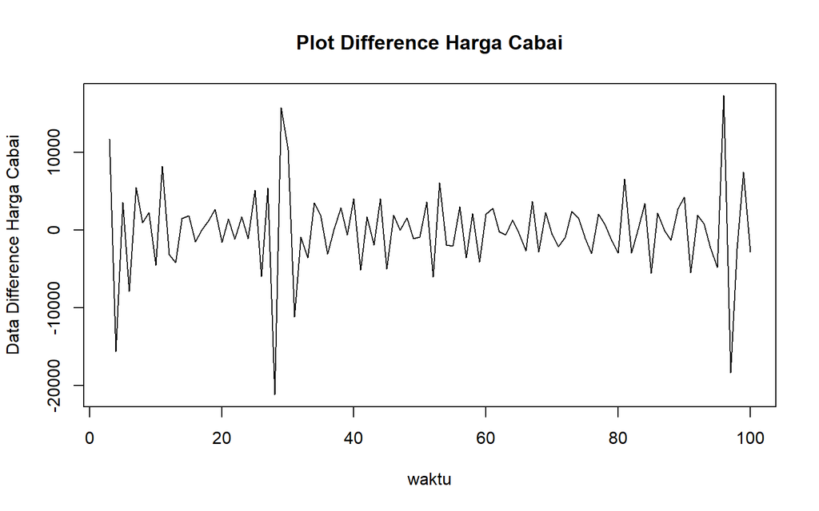

```r
train.diff<-diff(train.ts,differences = 2)
plot.ts(train.diff, lty=1, xlab="waktu", ylab="Data Difference Harga Cabai", main="Plot Difference Harga Cabai")
```

Berdasarkan plot data deret waktu, terlihat bahwa data sudah stasioner dalam rataan ditandai dengan data bergerak pada nilai tengah tertentu (tidak terdapat trend ataupun musiman pada data)

## Plot ACF

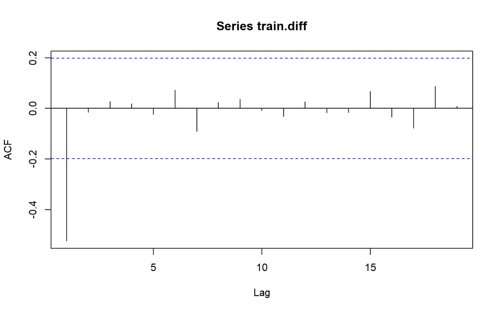

```r
acf(train.diff)
```

Berdasarkan plot tersebut, terlihat bahwa plot ACF cuts off pada lag ke 1. Hal ini menandakan data sudah stasioner dalam rataan dan ketidakstasioneran data telah berhasil tertangani.

## Uji ADF

```r
tseries::adf.test(train.diff)
```

```
##
##  Augmented Dickey-Fuller Test
##
## data:  train.diff
## Dickey-Fuller = -8.4919, Lag order = 4, p-value = 0.01
## alternative hypothesis: stationary
```

$H_0$ : Data tidak stasioner dalam rataan

$H_1$ : Data stasioner dalam rataan

Berdasarkan uji ADF tersebut, didapat *p-value* sebesar 0.01 yang lebih kecil dari taraf nyata 5% sehingga tolak $H_0$ atau data stasioner dalam rataan. Hal ini sesuai dengan hasil eksplorasi menggunakan plot time series dan plot ACF, sehingga dalam hal ini ketidakstasioneran data sudah berhasil ditangani dan dapat dilanjutkan ke pemodelan

# Identifikasi Model

## Plot ACF

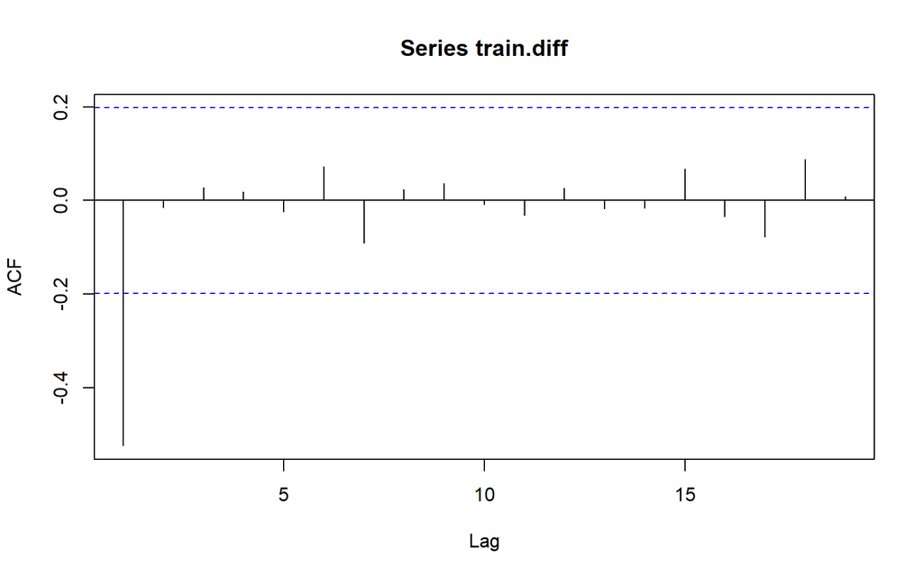

```r
acf(train.diff)
```

Berdasarkan plot tersebut, terlihat bahwa plot ACF cenderung *cuts off* pada lag ke 1, sehingga jika plot PACF dianggap *tails of*, maka model tentatifnya adalah ARIMA(0,2,1)

## Plot PACF

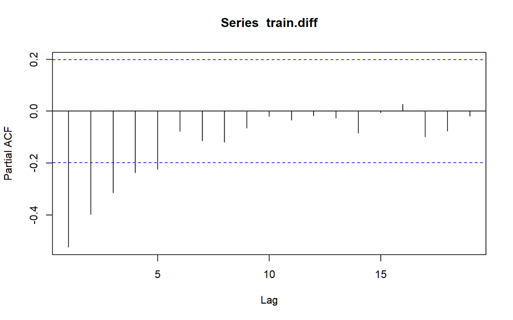

```r
pacf(train.diff)
```

Berdasarkan plot tersebut, terlihat bahwa plot PACF cenderung *cuts off* pada lag ke 5, sehingga jika plot ACF dianggap *tails of*, maka model tentatifnya adalah ARIMA(5,2,0).

Jika baik plot ACF maupun plot PACF keduanya dianggap tails of, maka model yang terbentuk adalah ARIMA(5,2,1)

## Plot EACF

```r
eacf(train.diff)
```

```
## AR/MA
##   0 1 2 3 4 5 6 7 8 9 10 11 12 13
## 0 x o o o o o o o o o o  o  o  o
## 1 x x o o o o o o o o o  o  o  o
## 2 x o x o o o o o o o o  o  o  o
## 3 x x o x o o o o o o o  o  o  o
## 4 x o o o o o o o o o o  o  o  o
## 5 x x x o o o o o o o o  o  o  o
## 6 x o o o o o o o o o o  o  o  o
## 7 x x o o o o o o o o o  o  o  o
```

Identifikasi model menggunakan plot EACF dilakukan dengan melihat ujung segitiga pada pola segitiga nol. Dalam hal ini model tentatif yang terbentuk adalah ARIMA(0,2,1), ARIMA(0,2,2), ARIMA(1,2,2), ARIMA(2,2,3), ARIMA(4,2,1)

# Pendugaan Parameter Model Tentatif

## ARIMA(0,2,1)

```r
model1.da=Arima(train.diff, order=c(0,0,1),method="ML")
summary(model1.da) #AIC=1893.61
```

```
## Series: train.diff
## ARIMA(0,0,1) with non-zero mean
##
## Coefficients:
##           ma1     mean
##       -1.0000  16.1206
## s.e.   0.0265  12.6682
##
## sigma^2 = 13219384:  log likelihood = -943.81
## AIC=1893.61   AICc=1893.87   BIC=1901.37
##
## Training set error measures:
##                     ME     RMSE      MAE  MPE MAPE     MASE       ACF1
## Training set -30.86232 3598.555 2373.288 -Inf  Inf 0.364166 -0.1434246
```

```r
lmtest::coeftest(model1.da) #seluruh parameter signifikan
```

```
##
## z test of coefficients:
##
##           Estimate Std. Error  z value Pr(>|z|)
## ma1       -1.00000    0.02646 -37.7932   <2e-16 ***
## intercept 16.12064   12.66817   1.2725   0.2032
## ---
## Signif. codes:  0 '***' 0.001 '**' 0.01 '*' 0.05 '.' 0.1 ' ' 1
```

## ARIMA(5,2,0)

```r
model2.da=Arima(train.diff, order=c(5,0,0),method="ML")
summary(model2.da) #AIC=1908.64
```

```
## Series: train.diff
## ARIMA(5,0,0) with non-zero mean
##
## Coefficients:
##           ar1      ar2      ar3      ar4      ar5      mean
##       -1.0057  -0.9562  -0.7802  -0.5505  -0.2824  -11.6436
## s.e.   0.0989   0.1430   0.1618   0.1582   0.1192   85.6004
##
## sigma^2 = 15261584:  log likelihood = -947.32
## AIC=1908.64   AICc=1909.89   BIC=1926.74
##
## Training set error measures:
##                     ME     RMSE      MAE MPE MAPE     MASE         ACF1
## Training set -58.56193 3785.129 2622.455 Inf  Inf 0.402399 -0.007891049
```

```r
lmtest::coeftest(model2.da) #seluruh parameter signifikan
```

```
##
## z test of coefficients:
##
##             Estimate Std. Error  z value  Pr(>|z|)
## ar1        -1.005687   0.098853 -10.1736 < 2.2e-16 ***
## ar2        -0.956161   0.143007  -6.6861 2.291e-11 ***
## ar3        -0.780199   0.161814  -4.8216 1.424e-06 ***
## ar4        -0.550459   0.158162  -3.4803 0.0005008 ***
## ar5        -0.282426   0.119166  -2.3700 0.0177874 *
## intercept -11.643643  85.600405  -0.1360 0.8918029
## ---
## Signif. codes:  0 '***' 0.001 '**' 0.01 '*' 0.05 '.' 0.1 ' ' 1
```

## ARIMA(5,2,1)

```r
model3.da=Arima(train.diff, order=c(5,0,1),method="ML")
summary(model3.da) #AIC=1899.01
```

```
## Series: train.diff
## ARIMA(5,0,1) with non-zero mean
##
## Coefficients:
##           ar1      ar2      ar3      ar4     ar5     ma1     mean
##       -0.1933  -0.1651  -0.0943  -0.0639  0.0102  -1.000  18.8908
## s.e.   0.1026   0.1107   0.1160   0.1169  0.1240   0.029   8.5315
##
## sigma^2 = 13183762:  log likelihood = -941.51
## AIC=1899.01   AICc=1900.63   BIC=1919.69
##
## Training set error measures:
##                    ME     RMSE      MAE  MPE MAPE      MASE        ACF1
## Training set 4.992139 3498.866 2416.909 -Inf  Inf 0.3708592 0.005667689
```

```r
lmtest::coeftest(model3.da) #terdapat parameter tidak signifikan
```

```
##
## z test of coefficients:
##
##            Estimate Std. Error  z value Pr(>|z|)
## ar1       -0.193255   0.102628  -1.8831  0.05969 .
## ar2       -0.165103   0.110728  -1.4911  0.13594
## ar3       -0.094303   0.115999  -0.8130  0.41624
## ar4       -0.063925   0.116907  -0.5468  0.58452
## ar5        0.010216   0.123967   0.0824  0.93432
## ma1       -0.999986   0.028964 -34.5250  < 2e-16 ***
## intercept 18.890834   8.531463   2.2143  0.02681 *
## ---
## Signif. codes:  0 '***' 0.001 '**' 0.01 '*' 0.05 '.' 0.1 ' ' 1
```

## ARIMA(0,2,2)

```r
model4.da=Arima(train.diff, order=c(0,0,2),method="ML")
summary(model4.da) #AIC=1892.73
```

```
## Series: train.diff
## ARIMA(0,0,2) with non-zero mean
##
## Coefficients:
##           ma1     ma2     mean
##       -1.1994  0.1994  16.8496
## s.e.   0.1201  0.1170  10.0711
##
## sigma^2 = 12907690:  log likelihood = -942.36
## AIC=1892.73   AICc=1893.16   BIC=1903.07
##
## Training set error measures:
##                     ME     RMSE      MAE  MPE MAPE      MASE       ACF1
## Training set -43.16505 3537.309 2437.761 -Inf  Inf 0.3740588 0.03292367
```

```r
lmtest::coeftest(model4.da) #seluruh parameter signifikan
```

```
##
## z test of coefficients:
##
##           Estimate Std. Error z value Pr(>|z|)
## ma1       -1.19939    0.12007 -9.9891  < 2e-16 ***
## ma2        0.19940    0.11700  1.7043  0.08833 .
## intercept 16.84957   10.07107  1.6731  0.09431 .
## ---
## Signif. codes:  0 '***' 0.001 '**' 0.01 '*' 0.05 '.' 0.1 ' ' 1
```

## ARIMA(1,2,2)

```r
model5.da=Arima(train.diff, order=c(1,0,2),method="ML")
summary(model5.da) #AIC=1890.3
```

```
## Series: train.diff
## ARIMA(1,0,2) with non-zero mean
##
## Coefficients:
##          ar1      ma1     ma2     mean
##       0.7783  -1.9989  1.0000  16.3161
## s.e.  0.0765   0.0595  0.0595   3.0042
##
## sigma^2 = 11892664:  log likelihood = -940.15
## AIC=1890.3   AICc=1890.96   BIC=1903.23
##
## Training set error measures:
##                    ME     RMSE      MAE  MPE MAPE      MASE        ACF1
## Training set 81.33425 3377.462 2283.513 -Inf  Inf 0.3503905 -0.03784076
```

```r
lmtest::coeftest(model5.da) #seluruh parameter signifikan
```

```
##
## z test of coefficients:
##
##            Estimate Std. Error  z value  Pr(>|z|)
## ar1        0.778303   0.076545  10.1679 < 2.2e-16 ***
## ma1       -1.998881   0.059523 -33.5815 < 2.2e-16 ***
## ma2        0.999957   0.059537  16.7957 < 2.2e-16 ***
## intercept 16.316128   3.004177   5.4311 5.599e-08 ***
## ---
## Signif. codes:  0 '***' 0.001 '**' 0.01 '*' 0.05 '.' 0.1 ' ' 1
```